# WEEK 13 Part2 IP R PROGRAMMING

#1. Defining the question

##a) Specifying the Data Analytic Question. `Classifying customers by studying and understanding their behavior from data collected over the past year while also learning the characteristics of customer groups.`

##b) Defining the metric of success `The project will be a success when we are able to identify the customers who are most likely to complete an e-commerce transaction by studying their online behavior.`

##c) Understanding the context `Kira Plastinina is a Russian brand that is sold through a defunct chain of retail stores in Russia, Ukraine, Kazakhstan, Belarus, China, Philippines, and Armenia. The brand’s Sales and Marketing team would like to understand their customer’s behavior from data that they have collected over the past year. More specifically, they would like to learn the characteristics of customer groups. Findings from the study will help inform the team on formulating marketing and sales strategies for the brand.`

##d) Recording the experimental design

`The process will entail:`

- Problem Definition
- Data Sourcing
- Check the Data
- Perform Data Cleaning
- Perform Exploratory Data Analysis (Univariate, Bivariate & Multivariate)
- Implement the Solution
- Challenge the Solution
- Follow up Questions

##e) Data relevance

`The dataset appropriate for this project will be one that contains characteristics of individuals who shop from Kira Plastinina. It's appropriateness will be measured against the metric of success. The following are the descriptions of the variables found within the dataset:`

- The dataset consists of 10 numerical and 8 categorical attributes. The ‘Revenue’ attribute can be used as the class label.
- “Administrative”, “Administrative Duration”, “Informational”, “Informational Duration”, “Product Related” and “Product Related Duration” represents the number of different types of pages visited by the visitor in that session and total time spent in each of these page categories. The values of these features are derived from the URL information of the pages visited by the user and updated in real-time when a user takes an action, e.g. moving from one page to another.
- The “Bounce Rate”, “Exit Rate” and “Page Value” features represent the metrics measured by “Google Analytics” for each page in the e-commerce site.
- The value of the “Bounce Rate” feature for a web page refers to the percentage of visitors who enter the site from that page and then leave (“bounce”) without triggering any other requests to the analytics server during that session.
- The value of the “Exit Rate” feature for a specific web page is calculated as for all pageviews to the page, the percentage that was the last in the session.
- The “Page Value” feature represents the average value for a web page that a user visited before completing an e-commerce transaction.
- The “Special Day” feature indicates the closeness of the site visiting time to a specific special day (e.g. Mother’s Day, Valentine’s Day) in which the sessions are more likely to be finalized with the transaction. The value of this attribute is determined by considering the dynamics of e-commerce such as the duration between the order date and delivery date. For example, for Valentine’s day, this value takes a nonzero value between February 2 and February 12, zero before and after this date unless it is close to another special day, and its maximum value of 1 on February 8.
- The dataset also includes the operating system, browser, region, traffic type, visitor type as returning or new visitor, a Boolean value indicating whether the date of the visit is weekend, and month of the year.

`[Ecommerce Customers Dataset](http://bit.ly/EcommerceCustomersDataset)`

#2. Reading the data

```r
ecommerce <- read.csv('online_shoppers_intention.csv')
```

#3. Checking the data

```r
#Viewing the first 6 entries
head(ecommerce)
```

```
##   Administrative Administrative_Duration Informational Informational_Duration
## 1              0                       0             0                      0
## 2              0                       0             0                      0
## 3              0                      -1             0                     -1
## 4              0                       0             0                      0
## 5              0                       0             0                      0
## 6              0                       0             0                      0
##   ProductRelated ProductRelated_Duration BounceRates ExitRates PageValues
## 1              1                0.000000  0.20000000 0.2000000          0
## 2              2               64.000000  0.00000000 0.1000000          0
## 3              1               -1.000000  0.20000000 0.2000000          0
## 4              2                2.666667  0.05000000 0.1400000          0
## 5             10              627.500000  0.02000000 0.0500000          0
## 6             19              154.216667  0.01578947 0.0245614          0
##   SpecialDay Month OperatingSystems Browser Region TrafficType
## 1          0   Feb                1       1      1           1
## 2          0   Feb                2       2      1           2
## 3          0   Feb                4       1      9           3
## 4          0   Feb                3       2      2           4
## 5          0   Feb                3       3      1           4
## 6          0   Feb                2       2      1           3
##         VisitorType Weekend Revenue
## 1 Returning_Visitor   FALSE   FALSE
## 2 Returning_Visitor   FALSE   FALSE
## 3 Returning_Visitor   FALSE   FALSE
## 4 Returning_Visitor   FALSE   FALSE
## 5 Returning_Visitor    TRUE   FALSE
## 6 Returning_Visitor   FALSE   FALSE
```

```r
#viewing the last 6 entries
tail(ecommerce)
```

```
##       Administrative Administrative_Duration Informational
## 12325              0                       0             1
## 12326              3                     145             0
## 12327              0                       0             0
## 12328              0                       0             0
## 12329              4                      75             0
## 12330              0                       0             0
##       Informational_Duration ProductRelated ProductRelated_Duration BounceRates
## 12325                      0             16                 503.000 0.000000000
## 12326                      0             53                1783.792 0.007142857
## 12327                      0              5                 465.750 0.000000000
## 12328                      0              6                 184.250 0.083333333
## 12329                      0             15                 346.000 0.000000000
## 12330                      0              3                  21.250 0.000000000
##        ExitRates PageValues SpecialDay Month OperatingSystems Browser Region
## 12325 0.03764706    0.00000          0   Nov                2       2      1
## 12326 0.02903061   12.24172          0   Dec                4       6      1
## 12327 0.02133333    0.00000          0   Nov                3       2      1
## 12328 0.08666667    0.00000          0   Nov                3       2      1
## 12329 0.02105263    0.00000          0   Nov                2       2      3
## 12330 0.06666667    0.00000          0   Nov                3       2      1
##       TrafficType       VisitorType Weekend Revenue
## 12325           1 Returning_Visitor   FALSE   FALSE
## 12326           1 Returning_Visitor    TRUE   FALSE
## 12327           8 Returning_Visitor    TRUE   FALSE
## 12328          13 Returning_Visitor    TRUE   FALSE
## 12329          11 Returning_Visitor   FALSE   FALSE
## 12330           2       New_Visitor    TRUE   FALSE
```

```r
#viewing the structure of the dataset
str(ecommerce)
```

```
## 'data.frame':    12330 obs. of  18 variables:
##  $ Administrative         : int  0 0 0 0 0 0 0 1 0 0 ...
##  $ Administrative_Duration: num  0 0 -1 0 0 0 -1 -1 0 0 ...
##  $ Informational          : int  0 0 0 0 0 0 0 0 0 0 ...
##  $ Informational_Duration : num  0 0 -1 0 0 0 -1 -1 0 0 ...
##  $ ProductRelated         : int  1 2 1 2 10 19 1 1 2 3 ...
##  $ ProductRelated_Duration: num  0 64 -1 2.67 627.5 ...
##  $ BounceRates            : num  0.2 0 0.2 0.05 0.02 ...
##  $ ExitRates              : num  0.2 0.1 0.2 0.14 0.05 ...
##  $ PageValues             : num  0 0 0 0 0 0 0 0 0 0 ...
##  $ SpecialDay             : num  0 0 0 0 0 0 0.4 0 0.8 0.4 ...
##  $ Month                  : chr  "Feb" "Feb" "Feb" "Feb" ...
##  $ OperatingSystems       : int  1 2 4 3 3 2 2 1 2 2 ...
##  $ Browser                : int  1 2 1 2 3 2 4 2 2 4 ...
##  $ Region                 : int  1 1 9 2 1 1 3 1 2 1 ...
##  $ TrafficType            : int  1 2 3 4 4 3 3 5 3 2 ...
##  $ VisitorType            : chr  "Returning_Visitor" "Returning_Visitor" "Returning_Visitor" "Returning_Visitor" ...
##  $ Weekend                : logi  FALSE FALSE FALSE FALSE TRUE FALSE ...
##  $ Revenue                : logi  FALSE FALSE FALSE FALSE FALSE FALSE ...
```

```r
#Finding the number of columns and rows
dim(ecommerce)
```

```
## [1] 12330    18
```

```r
#Statistical summary of our data set
summary(ecommerce)
```

```
##  Administrative   Administrative_Duration Informational
##  Min.   : 0.000   Min.   :  -1.00         Min.   : 0.000
##  1st Qu.: 0.000   1st Qu.:   0.00         1st Qu.: 0.000
##  Median : 1.000   Median :   8.00         Median : 0.000
##  Mean   : 2.318   Mean   :  80.91         Mean   : 0.504
##  3rd Qu.: 4.000   3rd Qu.:  93.50         3rd Qu.: 0.000
##  Max.   :27.000   Max.   :3398.75         Max.   :24.000
##  NA's   :14       NA's   :14              NA's   :14
##  Informational_Duration ProductRelated   ProductRelated_Duration
##  Min.   :  -1.00        Min.   :  0.00   Min.   :   -1.0
##  1st Qu.:   0.00        1st Qu.:  7.00   1st Qu.:  185.0
##  Median :   0.00        Median : 18.00   Median :  599.8
##  Mean   :  34.51        Mean   : 31.76   Mean   : 1196.0
##  3rd Qu.:   0.00        3rd Qu.: 38.00   3rd Qu.: 1466.5
##  Max.   :2549.38        Max.   :705.00   Max.   :63973.5
##  NA's   :14             NA's   :14       NA's   :14
##   BounceRates         ExitRates         PageValues        SpecialDay
##  Min.   :0.000000   Min.   :0.00000   Min.   :  0.000   Min.   :0.00000
##  1st Qu.:0.000000   1st Qu.:0.01429   1st Qu.:  0.000   1st Qu.:0.00000
##  Median :0.003119   Median :0.02512   Median :  0.000   Median :0.00000
##  Mean   :0.022152   Mean   :0.04300   Mean   :  5.889   Mean   :0.06143
##  3rd Qu.:0.016684   3rd Qu.:0.05000   3rd Qu.:  0.000   3rd Qu.:0.00000
##  Max.   :0.200000   Max.   :0.20000   Max.   :361.764   Max.   :1.00000
##  NA's   :14         NA's   :14
##     Month           OperatingSystems    Browser           Region
##  Length:12330       Min.   :1.000    Min.   : 1.000   Min.   :1.000
##  Class :character   1st Qu.:2.000    1st Qu.: 2.000   1st Qu.:1.000
##  Mode  :character   Median :2.000    Median : 2.000   Median :3.000
##                     Mean   :2.124    Mean   : 2.357   Mean   :3.147
##                     3rd Qu.:3.000    3rd Qu.: 2.000   3rd Qu.:4.000
##                     Max.   :8.000    Max.   :13.000   Max.   :9.000
##
##   TrafficType    VisitorType         Weekend         Revenue
##  Min.   : 1.00   Length:12330       Mode :logical   Mode :logical
##  1st Qu.: 2.00   Class :character   FALSE:9462      FALSE:10422
##  Median : 2.00   Mode  :character   TRUE :2868      TRUE :1908
##  Mean   : 4.07
##  3rd Qu.: 4.00
##  Max.   :20.00
##
```

#4. Tidying the data/ Data Cleaning

## Completeness

```r
#checking for missing values
colSums(is.na(ecommerce))
```

```
##          Administrative Administrative_Duration           Informational
##                      14                      14                      14
##  Informational_Duration          ProductRelated ProductRelated_Duration
##                      14                      14                      14
##             BounceRates               ExitRates              PageValues
##                      14                      14                       0
##              SpecialDay                   Month        OperatingSystems
##                       0                       0                       0
##                 Browser                  Region             TrafficType
##                       0                       0                       0
##             VisitorType                 Weekend                 Revenue
##                       0                       0                       0
```

```r
#Removing the missing values
ec <- na.omit(ecommerce)
colSums(is.na(ec))
```

```
##          Administrative Administrative_Duration           Informational
##                       0                       0                       0
##  Informational_Duration          ProductRelated ProductRelated_Duration
##                       0                       0                       0
##             BounceRates               ExitRates              PageValues
##                       0                       0                       0
##              SpecialDay                   Month        OperatingSystems
##                       0                       0                       0
##                 Browser                  Region             TrafficType
##                       0                       0                       0
##             VisitorType                 Weekend                 Revenue
##                       0                       0                       0
```

```r
dim(ec)
```

```
## [1] 12316    18
```

## consistency

```r
#checking for duplicates
anyDuplicated(ec)
```

```
## [1] 159
```

```r
#removing duplicates
ec <- unique(ec)
dim(ec)
```

```
## [1] 12199    18
```

```r
#convert categorical columns to factors
ec[,11:18] <- sapply(ec[,11:18], as.factor)
head(ec)
```

```
##   Administrative Administrative_Duration Informational Informational_Duration
## 1              0                       0             0                      0
## 2              0                       0             0                      0
## 3              0                      -1             0                     -1
## 4              0                       0             0                      0
## 5              0                       0             0                      0
## 6              0                       0             0                      0
##   ProductRelated ProductRelated_Duration BounceRates ExitRates PageValues
## 1              1                0.000000  0.20000000 0.2000000          0
## 2              2               64.000000  0.00000000 0.1000000          0
## 3              1               -1.000000  0.20000000 0.2000000          0
## 4              2                2.666667  0.05000000 0.1400000          0
## 5             10              627.500000  0.02000000 0.0500000          0
## 6             19              154.216667  0.01578947 0.0245614          0
##   SpecialDay Month OperatingSystems Browser Region TrafficType
## 1          0   Feb                1       1      1           1
## 2          0   Feb                2       2      1           2
## 3          0   Feb                4       1      9           3
## 4          0   Feb                3       2      2           4
## 5          0   Feb                3       3      1           4
## 6          0   Feb                2       2      1           3
##         VisitorType Weekend Revenue
## 1 Returning_Visitor   FALSE   FALSE
## 2 Returning_Visitor   FALSE   FALSE
## 3 Returning_Visitor   FALSE   FALSE
## 4 Returning_Visitor   FALSE   FALSE
## 5 Returning_Visitor    TRUE   FALSE
## 6 Returning_Visitor   FALSE   FALSE
```

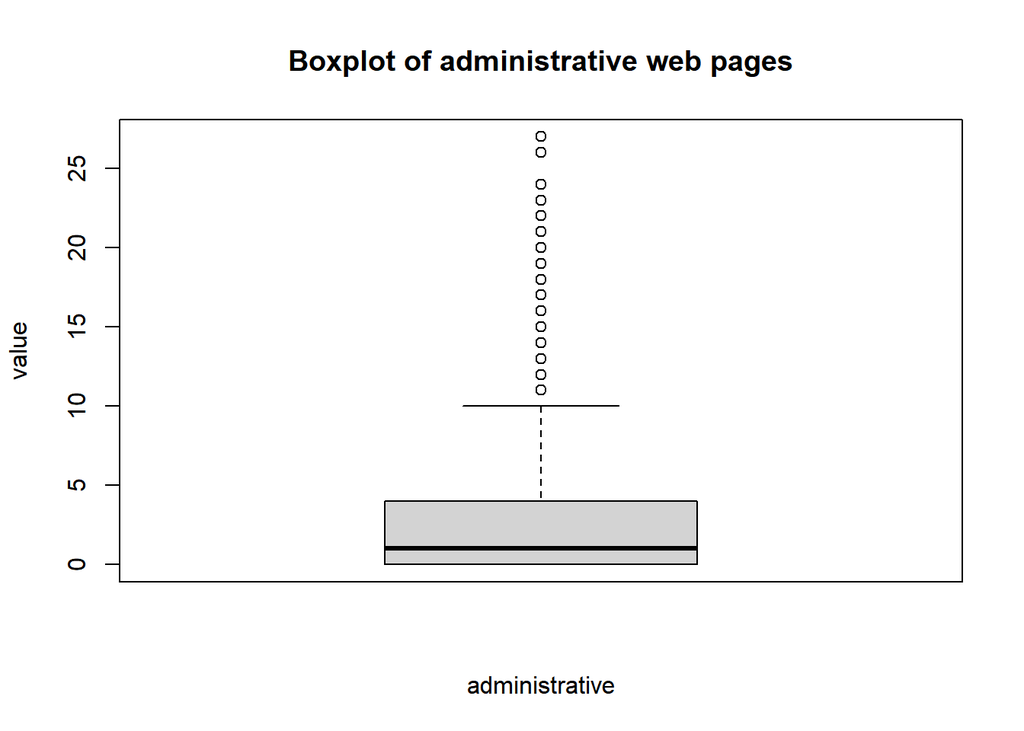

```r
#checking for outliers
#list(colnames(ec))

boxplot(ec$Administrative, main= 'Boxplot of administrative web pages', xlab='administrative', ylab='value')
```

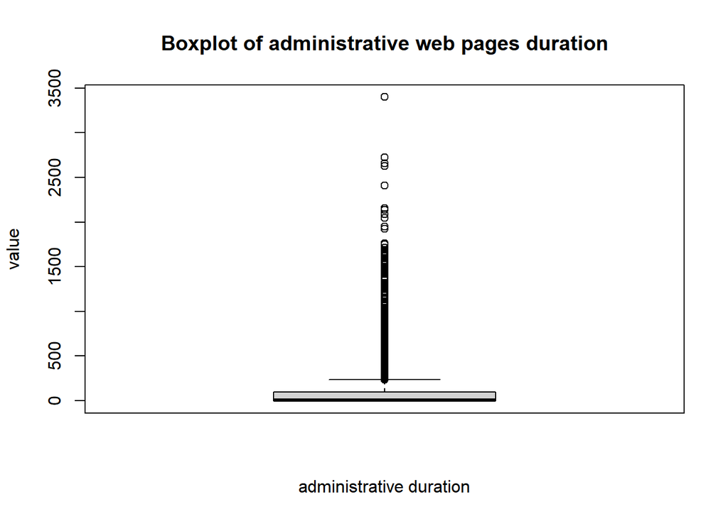

```r
boxplot(ec$Administrative_Duration, main= 'Boxplot of administrative web pages duration', xlab='administrative duration', ylab='value')
```

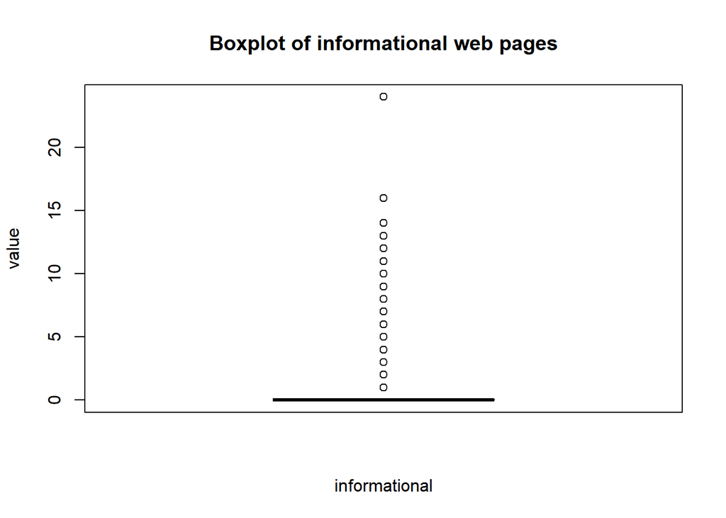

```r
boxplot(ec$Informational, main= 'Boxplot of informational web pages', xlab='informational', ylab='value')
```

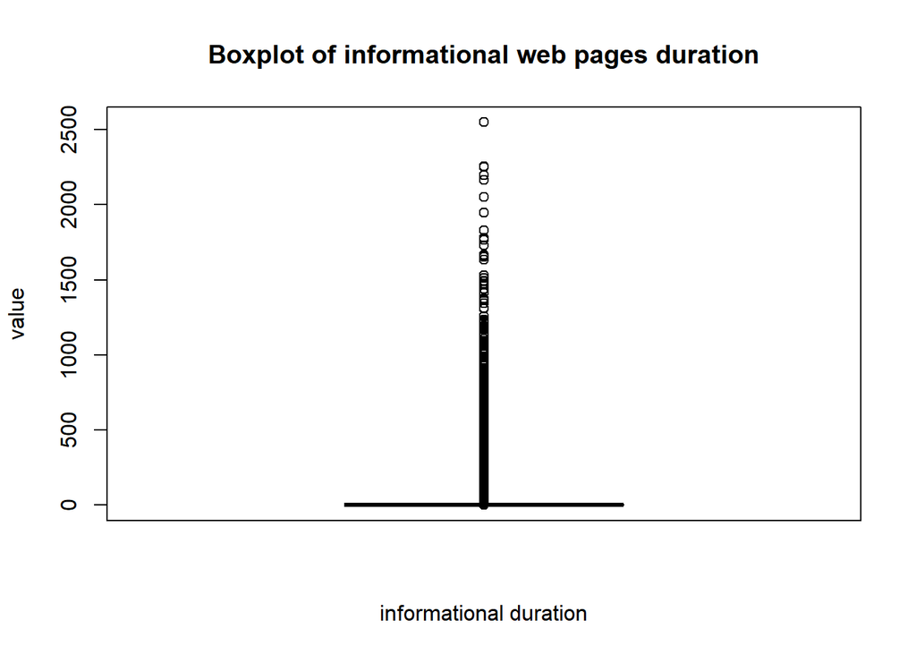

```r
boxplot(ec$Informational_Duration, main= 'Boxplot of informational web pages duration', xlab='informational duration', ylab='value')
```

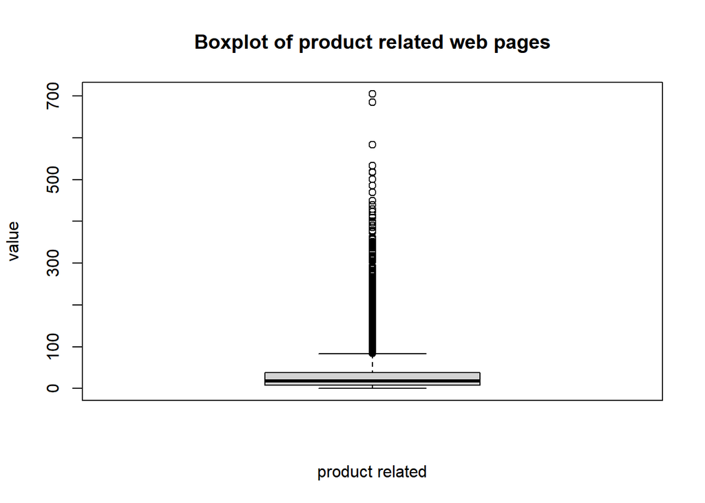

```r
boxplot(ec$ProductRelated, main= 'Boxplot of product related web pages', xlab='product related', ylab='value')
```

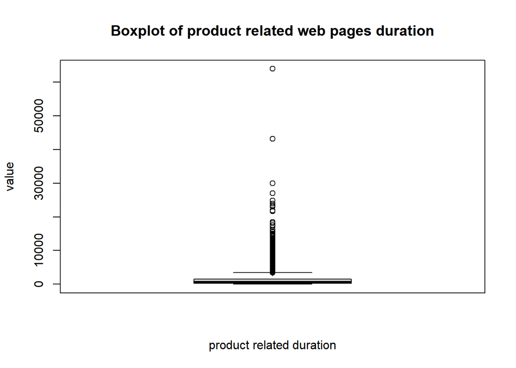

```r
boxplot(ec$ProductRelated_Duration, main= 'Boxplot of product related web pages duration', xlab='product related duration', ylab='value')
```

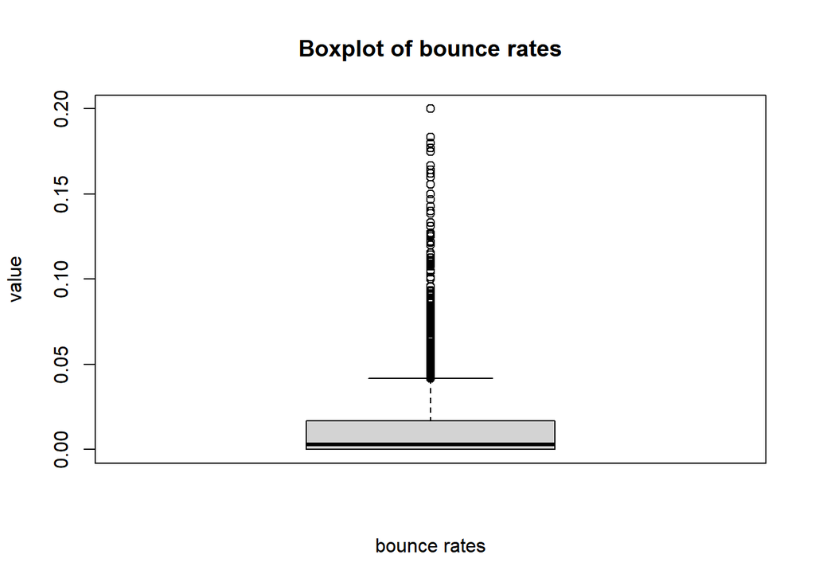

```r
boxplot(ec$BounceRates, main= 'Boxplot of bounce rates', xlab='bounce rates', ylab='value')
```

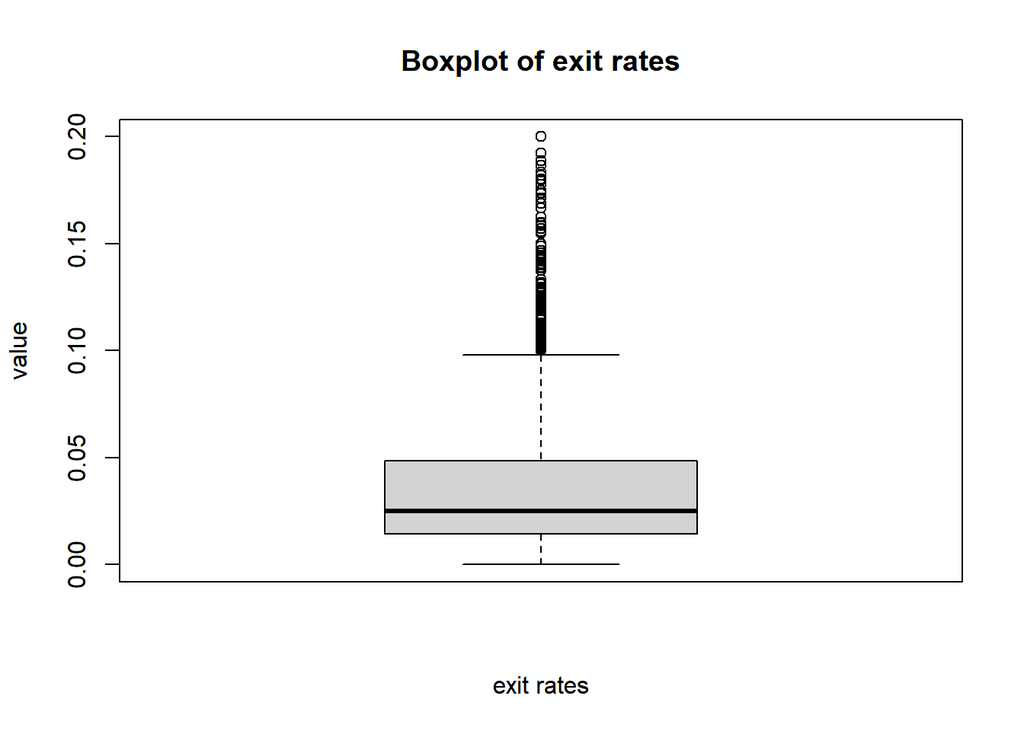

```r
boxplot(ec$ExitRates, main= 'Boxplot of exit rates', xlab='exit rates', ylab='value')
```

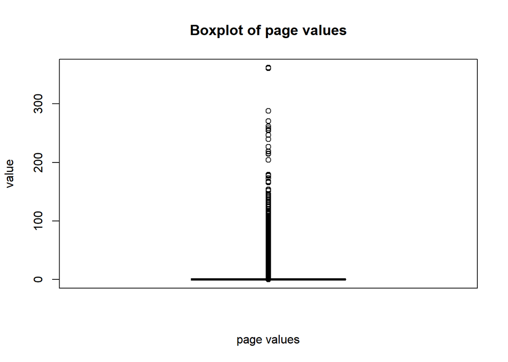

```r
boxplot(ec$PageValues, main= 'Boxplot of page values', xlab='page values', ylab='value')
```

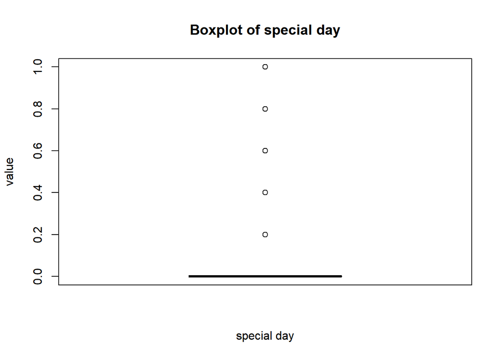

```r
boxplot(ec$SpecialDay, main= 'Boxplot of special day', xlab='special day', ylab='value')
```

`There are outliers in every column but we wunt remove them as they might give insight to the project.`

#5. Univariate Exploratory Data Analysis

## Measures of central tendancy

```r
#finding the mean
mean <- colMeans(ec[sapply(ec, is.numeric)])
mean
```

```
##          Administrative Administrative_Duration           Informational
##            2.340028e+00            8.168214e+01            5.088122e-01
##  Informational_Duration          ProductRelated ProductRelated_Duration
##            3.483734e+01            3.205845e+01            1.207508e+03
##             BounceRates               ExitRates              PageValues
##            2.044674e-02            4.149678e-02            5.952500e+00
##              SpecialDay
##            6.197229e-02
```

```r
#Finding the median
#loading the tidyverse and robustbase(for the colMedians function) libraries
library(robustbase)
library(tidyverse)
median <- ec%>%
  select_if(is.numeric) %>%
  as.matrix()%>%
  colMedians()
print(median)
```

```
##          Administrative Administrative_Duration           Informational
##            1.000000e+00            9.000000e+00            0.000000e+00
##  Informational_Duration          ProductRelated ProductRelated_Duration
##            0.000000e+00            1.800000e+01            6.095417e+02
##             BounceRates               ExitRates              PageValues
##            2.930403e-03            2.500000e-02            0.000000e+00
##              SpecialDay
##            0.000000e+00
```

```r
#Finding the mode
mode <- function(v) {
   uniqv <- unique(v)
   uniqv[which.max(tabulate(match(v, uniqv)))]
}


mode(ec$Administrative)
```

```
## [1] 0
```

```r
mode(ec$Administrative_Duration)
```

```
## [1] 0
```

```r
mode(ec$Informational)
```

```
## [1] 0
```

```r
mode(ec$Informational_Duration)
```

```
## [1] 0
```

```r
mode(ec$ProductRelated)
```

```
## [1] 1
```

```r
mode(ec$ProductRelated_Duration)
```

```
## [1] 0
```

```r
mode(ec$BounceRates)
```

```
## [1] 0
```

```r
mode(ec$ExitRates)
```

```
## [1] 0.2
```

```r
mode(ec$PageValues)
```

```
## [1] 0
```

```r
mode(ec$SpecialDay)
```

```
## [1] 0
```

##Measures of dispersion

```r
#finding the minimum
min(ec$Administrative)
```

```
## [1] 0
```

```r
min(ec$Administrative_Duration)
```

```
## [1] -1
```

```r
min(ec$Informational)
```

```
## [1] 0
```

```r
min(ec$Informational_Duration)
```

```
## [1] -1
```

```r
min(ec$ProductRelated)
```

```
## [1] 0
```

```r
min(ec$ProductRelated_Duration)
```

```
## [1] -1
```

```r
min(ec$BounceRates)
```

```
## [1] 0
```

```r
min(ec$ExitRates)
```

```
## [1] 0
```

```r
min(ec$PageValues)
```

```
## [1] 0
```

```r
min(ec$SpecialDay)
```

```
## [1] 0
```

```r
#finding the maximum
max(ec$Administrative)
```

```
## [1] 27
```

```r
max(ec$Administrative_Duration)
```

```
## [1] 3398.75
```

```r
max(ec$Informational)
```

```
## [1] 24
```

```r
max(ec$Informational_Duration)
```

```
## [1] 2549.375
```

```r
max(ec$ProductRelated)
```

```
## [1] 705
```

```r
max(ec$ProductRelated_Duration)
```

```
## [1] 63973.52
```

```r
max(ec$BounceRates)
```

```
## [1] 0.2
```

```r
max(ec$ExitRates)
```

```
## [1] 0.2
```

```r
max(ec$PageValues)
```

```
## [1] 361.7637
```

```r
max(ec$SpecialDay)
```

```
## [1] 1
```

```r
#finding the range
range(ec$Administrative)
```

```
## [1]  0 27
```

```r
range(ec$Administrative_Duration)
```

```
## [1]   -1.00 3398.75
```

```r
range(ec$Informational)
```

```
## [1]  0 24
```

```r
range(ec$Informational_Duration)
```

```
## [1]   -1.000 2549.375
```

```r
range(ec$ProductRelated)
```

```
## [1]   0 705
```

```r
range(ec$ProductRelated_Duration)
```

```
## [1]    -1.00 63973.52
```

```r
range(ec$BounceRates)
```

```
## [1] 0.0 0.2
```

```r
range(ec$ExitRates)
```

```
## [1] 0.0 0.2
```

```r
range(ec$PageValues)
```

```
## [1]   0.0000 361.7637
```

```r
range(ec$SpecialDay)
```

```
## [1] 0 1
```

```r
#finding the quantile
quantile(ec$Administrative)
```

```
##   0%  25%  50%  75% 100%
##    0    0    1    4   27
```

```r
quantile(ec$Administrative_Duration)
```

```
##      0%     25%     50%     75%    100%
##   -1.00    0.00    9.00   94.75 3398.75
```

```r
quantile(ec$Informational)
```

```
##   0%  25%  50%  75% 100%
##    0    0    0    0   24
```

```r
quantile(ec$Informational_Duration)
```

```
##       0%      25%      50%      75%     100%
##   -1.000    0.000    0.000    0.000 2549.375
```

```r
quantile(ec$ProductRelated)
```

```
##   0%  25%  50%  75% 100%
##    0    8   18   38  705
```

```r
quantile(ec$ProductRelated_Duration)
```

```
##         0%        25%        50%        75%       100%
##    -1.0000   193.5833   609.5417  1477.5648 63973.5222
```

```r
quantile(ec$BounceRates)
```

```
##          0%         25%         50%         75%        100%
## 0.000000000 0.000000000 0.002930403 0.016666667 0.200000000
```

```r
quantile(ec$ExitRates)
```

```
##         0%        25%        50%        75%       100%
## 0.00000000 0.01422258 0.02500000 0.04848485 0.20000000
```

```r
quantile(ec$PageValues)
```

```
##       0%      25%      50%      75%     100%
##   0.0000   0.0000   0.0000   0.0000 361.7637
```

```r
quantile(ec$SpecialDay)
```

```
##   0%  25%  50%  75% 100%
##    0    0    0    0    1
```

```r
#finding the standard deviation
sd(ec$Administrative)
```

```
## [1] 3.330851
```

```r
sd(ec$Administrative_Duration)
```

```
## [1] 177.5282
```

```r
sd(ec$Informational)
```

```
## [1] 1.275817
```

```r
sd(ec$Informational_Duration)
```

```
## [1] 141.4585
```

```r
sd(ec$ProductRelated)
```

```
## [1] 44.60091
```

```r
sd(ec$ProductRelated_Duration)
```

```
## [1] 1919.927
```

```r
sd(ec$BounceRates)
```

```
## [1] 0.0454025
```

```r
sd(ec$ExitRates)
```

```
## [1] 0.04624716
```

```r
sd(ec$PageValues)
```

```
## [1] 18.65779
```

```r
sd(ec$SpecialDay)
```

```
## [1] 0.1997106
```

```r
#finding variance
var(ec$Administrative)
```

```
## [1] 11.09457
```

```r
var(ec$Administrative_Duration)
```

```
## [1] 31516.25
```

```r
var(ec$Informational)
```

```
## [1] 1.62771
```

```r
var(ec$Informational_Duration)
```

```
## [1] 20010.51
```

```r
var(ec$ProductRelated)
```

```
## [1] 1989.241
```

```r
var(ec$ProductRelated_Duration)
```

```
## [1] 3686121
```

```r
var(ec$BounceRates)
```

```
## [1] 0.002061387
```

```r
var(ec$ExitRates)
```

```
## [1] 0.0021388
```

```r
var(ec$PageValues)
```

```
## [1] 348.1132
```

```r
var(ec$SpecialDay)
```

```
## [1] 0.03988432
```

```r
#finding kurtosis
library(e1071)
skewness(ec$Administrative)
```

```
## [1] 1.946009
```

```r
skewness(ec$Administrative_Duration)
```

```
## [1] 5.589523
```

```r
skewness(ec$Informational)
```

```
## [1] 4.012958
```

```r
skewness(ec$Informational_Duration)
```

```
## [1] 7.536508
```

```r
skewness(ec$ProductRelated)
```

```
## [1] 4.331601
```

```r
skewness(ec$ProductRelated_Duration)
```

```
## [1] 7.250512
```

```r
skewness(ec$BounceRates)
```

```
## [1] 3.152486
```

```r
skewness(ec$ExitRates)
```

```
## [1] 2.232851
```

```r
skewness(ec$PageValues)
```

```
## [1] 6.347882
```

```r
skewness(ec$SpecialDay)
```

```
## [1] 3.284077
```

```r
#finding skewness
kurtosis(ec$Administrative)
```

```
## [1] 4.634854
```

```r
kurtosis(ec$Administrative_Duration)
```

```
## [1] 50.08518
```

```r
kurtosis(ec$Informational)
```

```
## [1] 26.63768
```

```r
kurtosis(ec$Informational_Duration)
```

```
## [1] 75.45122
```

```r
kurtosis(ec$ProductRelated)
```

```
## [1] 31.04345
```

```r
kurtosis(ec$ProductRelated_Duration)
```

```
## [1] 136.5679
```

```r
kurtosis(ec$BounceRates)
```

```
## [1] 9.253055
```

```r
kurtosis(ec$ExitRates)
```

```
## [1] 4.623003
```

```r
kurtosis(ec$PageValues)
```

```
## [1] 64.92917
```

```r
kurtosis(ec$SpecialDay)
```

```
## [1] 9.783958
```

## Univariate Analysis Graphicals

### Categorical columns

```r
#colnames(ec)
#frequency table of month
month.freq <- table(ec$Month)
sort(month.freq, decreasing = TRUE)[1:5]
```

```
##
##  May  Nov  Mar  Dec  Oct
## 3328 2983 1853 1706  549
```

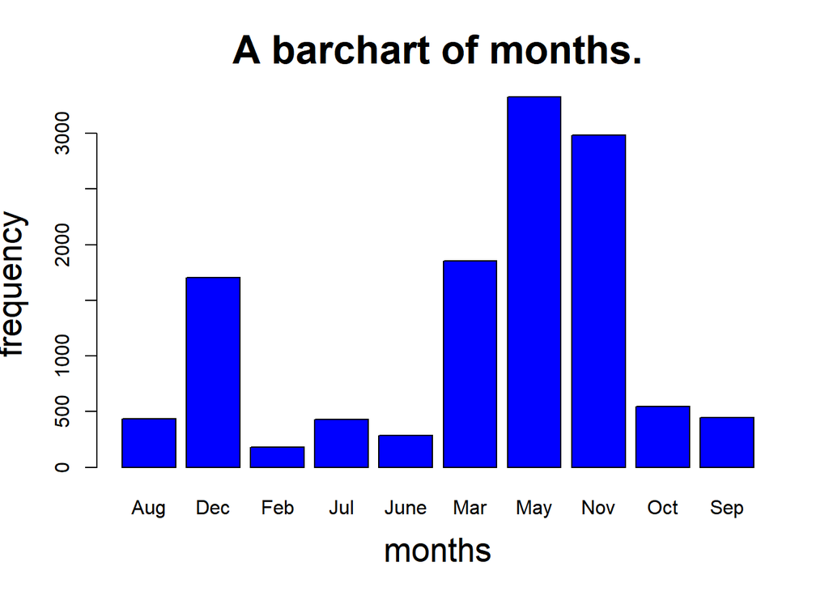

```r
#Bar chart to show frequency distribution of months
options(repr.plot.width = 10, repr.plot.height = 10)
barplot(c(month.freq), main="A barchart of months.",
        xlab="months",
        ylab="frequency",
        cex.main=2, cex.lab=1.7,cex.sub=1.2,
        col=c("blue"))
```

```r
#frequency table of Operating systems
os.freq <- table(ec$OperatingSystems)
sort(os.freq, decreasing = TRUE)[1:5]
```

```
##
##    2    1    3    4    8
## 6536 2548 2530  478   75
```

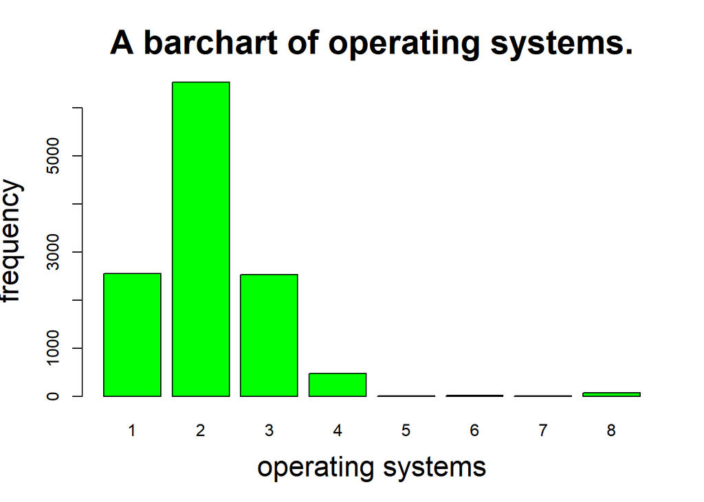

```r
#Bar chart to show frequency distribution of operating systems
options(repr.plot.width = 10, repr.plot.height = 10)
barplot(c(os.freq), main="A barchart of operating systems.",
        xlab="operating systems",
        ylab="frequency",
        cex.main=2, cex.lab=1.7,cex.sub=1.2,
        col=c("green"))
```

```r
#frequency table of browser
browser.freq <- table(ec$Browser)
sort(browser.freq, decreasing = TRUE)[1:5]
```

```
##
##    2    1    4    5    6
## 7878 2426  730  466  174
```

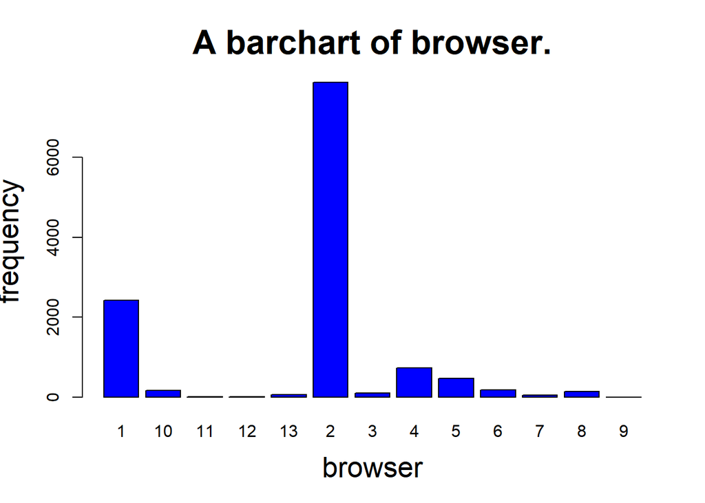

```r
#Bar chart to show frequency distribution of browsers
options(repr.plot.width = 10, repr.plot.height = 10)
barplot(c(browser.freq), main="A barchart of browser.",
        xlab="browser",
        ylab="frequency",
        cex.main=2, cex.lab=1.7,cex.sub=1.2,
        col=c("blue"))
```

```r
#frequency table of region
region.freq <- table(ec$Region)
sort(region.freq, decreasing = TRUE)[1:5]
```

```
##
##    1    3    4    2    6
## 4711 2382 1168 1127  800
```

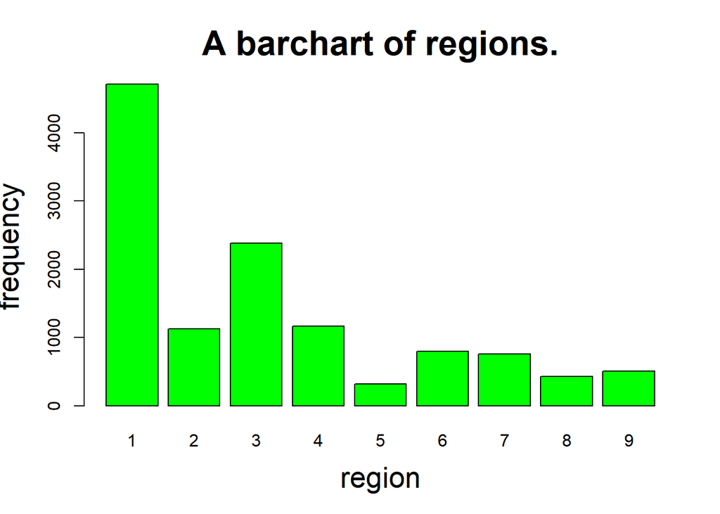

```r
#Bar chart to show frequency distribution of regions
options(repr.plot.width = 10, repr.plot.height = 10)
barplot(c(region.freq), main="A barchart of regions.",
        xlab="region",
        ylab="frequency",
        cex.main=2, cex.lab=1.7,cex.sub=1.2,
        col=c("green"))
```

```r
#frequency table of traffic type
traffic.freq <- table(ec$TrafficType)
sort(traffic.freq, decreasing = TRUE)[1:5]
```

```
##
##    2    1    3    4   13
## 3907 2383 2017 1066  728
```

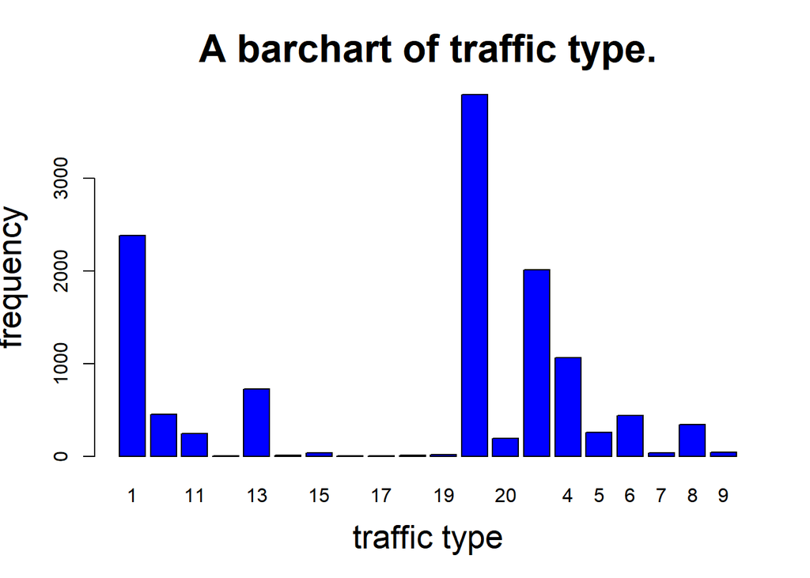

```r
#Bar chart to show frequency distribution of traffic type
options(repr.plot.width = 10, repr.plot.height = 10)
barplot(c(traffic.freq), main="A barchart of traffic type.",
        xlab="traffic type",
        ylab="frequency",
        cex.main=2, cex.lab=1.7,cex.sub=1.2,
        col=c("blue"))
```

```r
#frequency table of visitor type
visitor.freq <- table(ec$VisitorType)
sort(visitor.freq, decreasing = TRUE)[1:5]
```

```
##
## Returning_Visitor       New_Visitor             Other              <NA>
##             10425              1693                81
##              <NA>
##
```

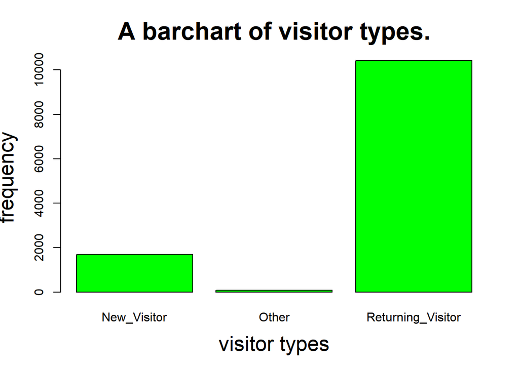

```r
#Bar chart to show frequency distribution of visitor type
options(repr.plot.width = 10, repr.plot.height = 10)
barplot(c(visitor.freq), main="A barchart of visitor types.",
        xlab="visitor types",
        ylab="frequency",
        cex.main=2, cex.lab=1.7,cex.sub=1.2,
        col=c("green"))
```

```r
#frequency table of weekend
weekend.freq <- table(ec$Weekend)
sort(weekend.freq, decreasing = TRUE)[1:5]
```

```
##
## FALSE  TRUE  <NA>  <NA>  <NA>
##  9343  2856
```

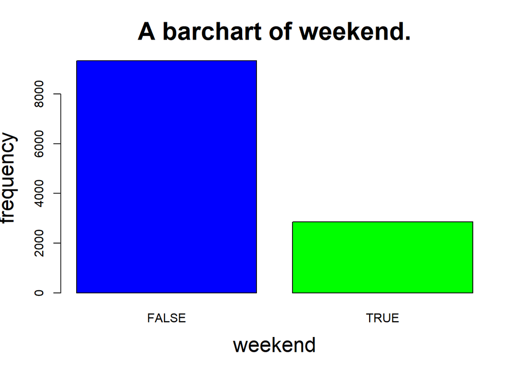

```r
#Bar chart to show frequency distribution of weekend
options(repr.plot.width = 10, repr.plot.height = 10)
barplot(c(weekend.freq), main="A barchart of weekend.",
        xlab="weekend",
        ylab="frequency",
        cex.main=2, cex.lab=1.7,cex.sub=1.2,
        col=c("blue", "green"))
```

```r
#frequency table of revenue
rev.freq <- table(ec$Revenue)
sort(rev.freq, decreasing = TRUE)[1:5]
```

```
##
## FALSE  TRUE  <NA>  <NA>  <NA>
## 10291  1908
```

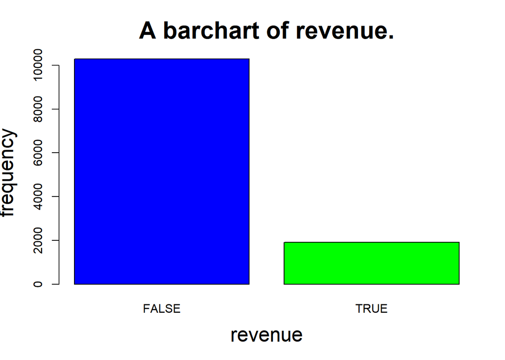

```r
#Bar chart to show frequency distribution of revenue
options(repr.plot.width = 10, repr.plot.height = 10)
barplot(c(rev.freq), main="A barchart of revenue.",
        xlab="revenue",
        ylab="frequency",
        cex.main=2, cex.lab=1.7,cex.sub=1.2,
        col=c("blue", "green"))
```

### Numerical variables

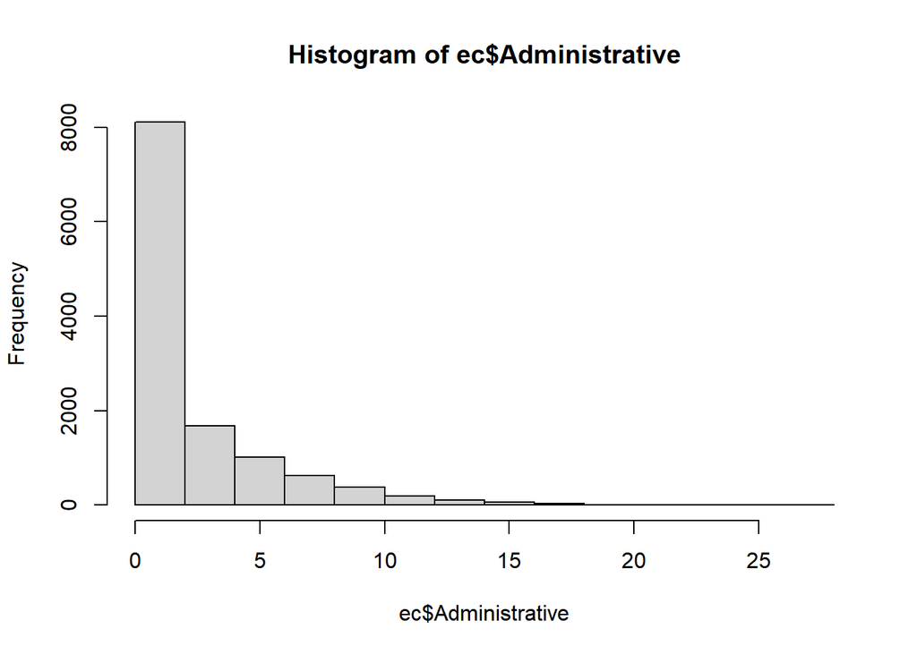

```r
#colnames(ec)
#creating a histogram of administrative variable.
hist(ec$Administrative)
```

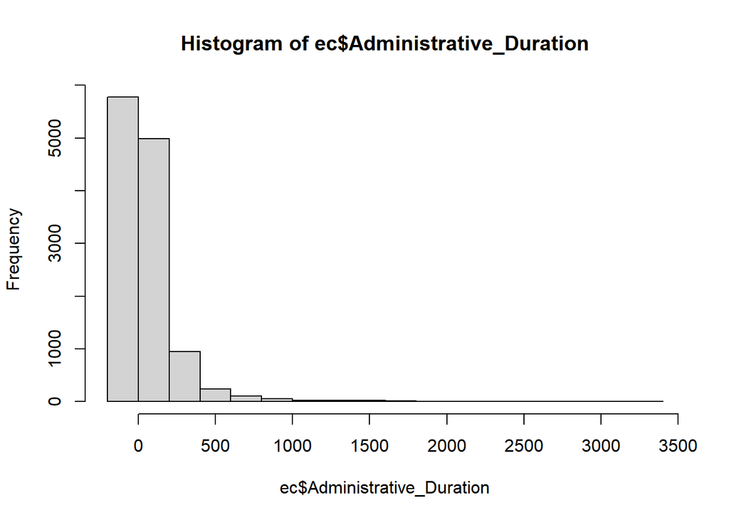

```r
#creating a histogram of administrative duration variable
hist(ec$Administrative_Duration)
```

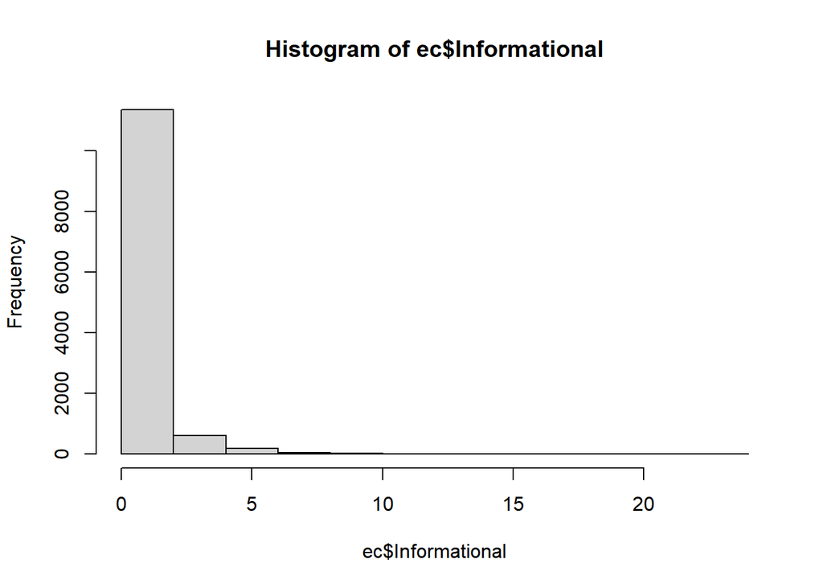

```r
#creating a histogram of informational variable
hist(ec$Informational)
```

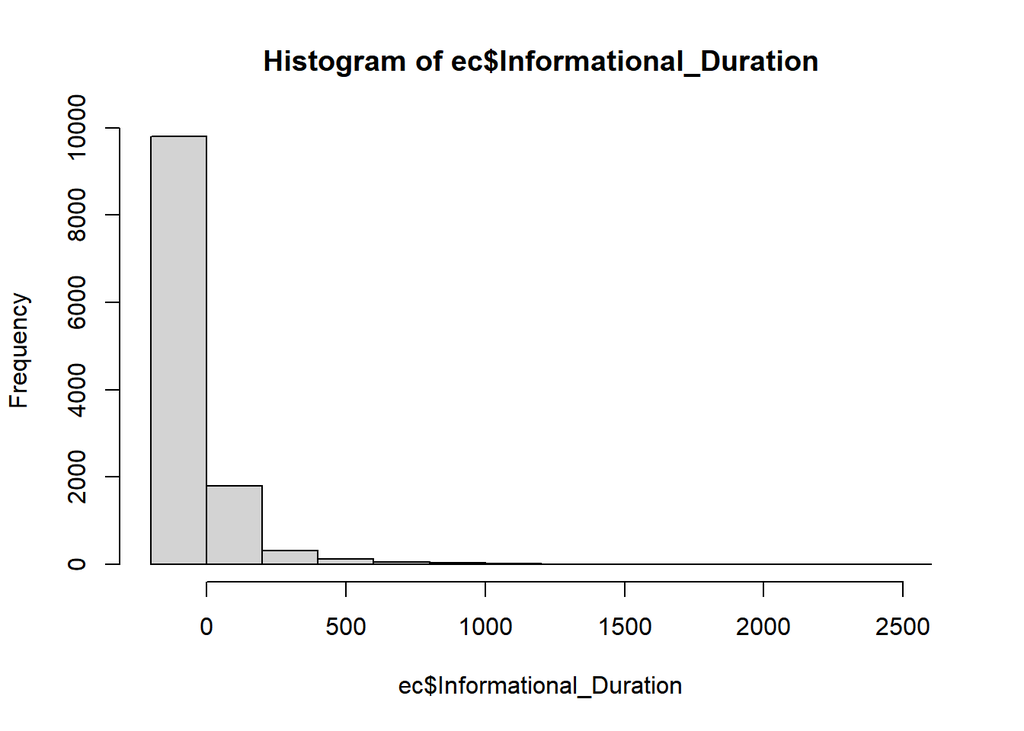

```r
#creating a histogram of informational duration variable
hist(ec$Informational_Duration)
```

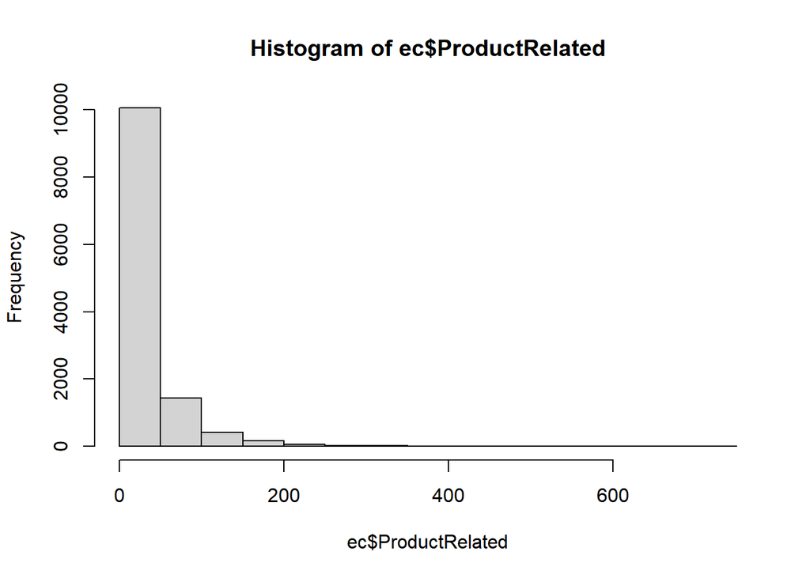

```r
#creating a histogram of product related variable
hist(ec$ProductRelated)
```

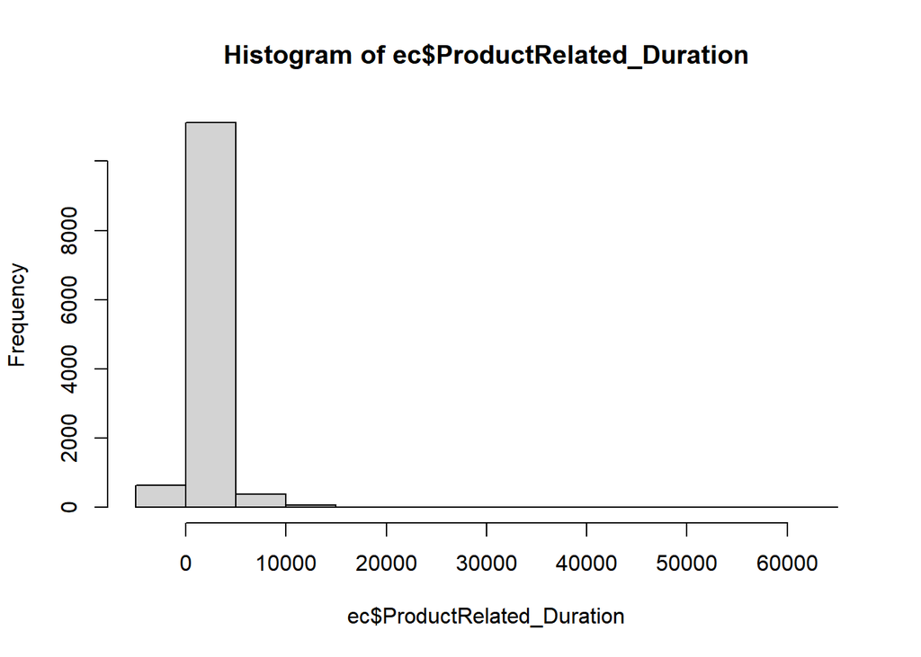

```r
#creating a histogram of product related duration variable
hist(ec$ProductRelated_Duration)
```

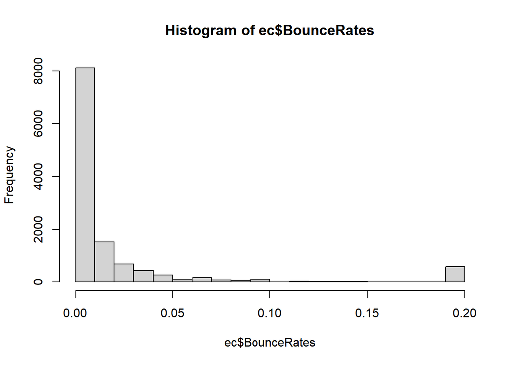

```r
#creating a histogram of bounce rates variable
hist(ec$BounceRates)
```

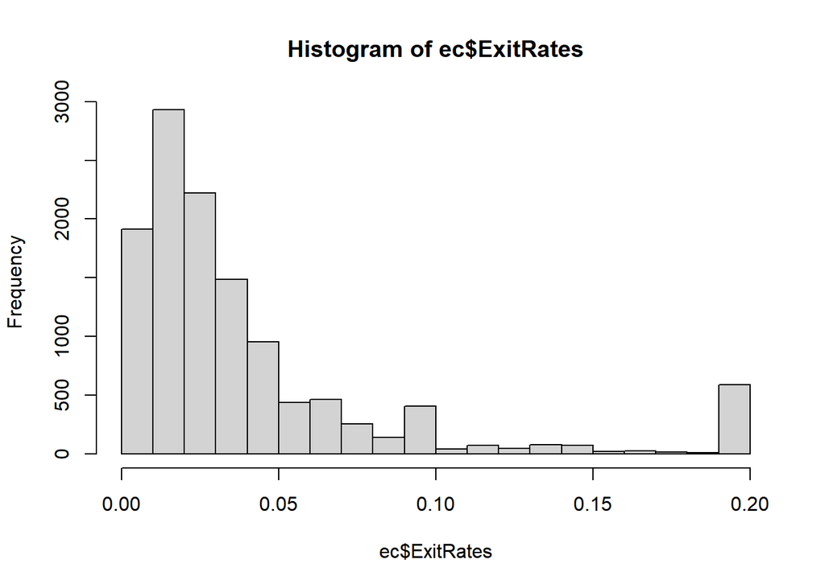

```r
#creating a histogram of exit rates variable
hist(ec$ExitRates)
```

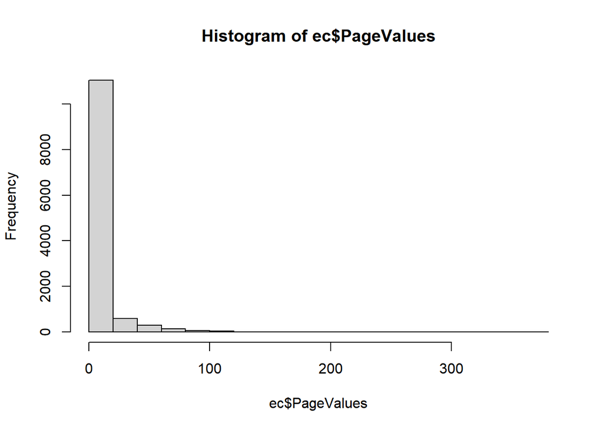

```r
#creating a histogram of page values variable
hist(ec$PageValues)
```

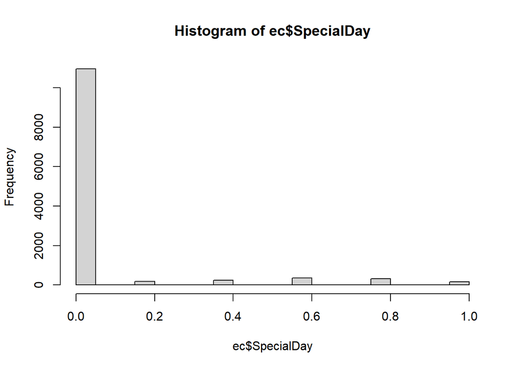

```r
#creating a histogram of special day variable
hist(ec$SpecialDay)
```

### Observations from univariate analysis

- May has the most web page visits.
- Type 2 operating systenm is the most used.
- Browser type 2 is the most used.
- The highest number of individuals in the dataset came from region 1
- Traffic type 2 got most entries.
- Returning visitors formed the larger portion of the data.
- More web page visits were made during the weekday.
- There was lesser revenue.

#6. Bivariate & Multivariate Analysis

```r
#finding the covariance
cov <- cov(ec[,unlist(lapply(ec, is.numeric))])
cov
```

```
##                         Administrative Administrative_Duration Informational
## Administrative             11.09456996              355.034186   1.594806280
## Administrative_Duration   355.03418646            31516.250360  68.273361883
## Informational               1.59480628               68.273362   1.627709681
## Informational_Duration    120.04936778             5956.517671 111.656022657
## ProductRelated             63.61170357             2270.731540  21.202182071
## ProductRelated_Duration  2372.71642208           120492.067559 945.703033133
## BounceRates                -0.03231259               -1.106938  -0.006343127
## ExitRates                  -0.04794942               -1.658656  -0.009414909
## PageValues                  6.02328225              219.168388   1.128072018
## SpecialDay                 -0.06457297               -2.649741  -0.012580917
##                         Informational_Duration ProductRelated
## Administrative                     120.0493678     63.6117036
## Administrative_Duration           5956.5176708   2270.7315396
## Informational                      111.6560227     21.2021821
## Informational_Duration           20010.5068642   1760.6514935
## ProductRelated                    1760.6514935   1989.2412959
## ProductRelated_Duration          94127.8699847  73668.6330189
## BounceRates                         -0.4506041     -0.3918681
## ExitRates                           -0.6733911     -0.5902590
## PageValues                          79.3484334     45.0324519
## SpecialDay                          -0.8840522     -0.2309712
##                         ProductRelated_Duration   BounceRates     ExitRates
## Administrative                       2372.71642 -3.231259e-02  -0.047949418
## Administrative_Duration            120492.06756 -1.106938e+00  -1.658655837
## Informational                         945.70303 -6.343127e-03  -0.009414909
## Informational_Duration              94127.86998 -4.506041e-01  -0.673391128
## ProductRelated                      73668.63302 -3.918681e-01  -0.590258984
## ProductRelated_Duration           3686121.49674 -1.520023e+01 -21.783499809
## BounceRates                           -15.20023  2.061387e-03   0.001896814
## ExitRates                             -21.78350  1.896814e-03   0.002138800
## PageValues                           1821.19283 -9.825801e-02  -0.149769655
## SpecialDay                            -14.65110  7.964769e-04   0.001078620
##                            PageValues    SpecialDay
## Administrative             6.02328225 -6.457297e-02
## Administrative_Duration  219.16838756 -2.649741e+00
## Informational              1.12807202 -1.258092e-02
## Informational_Duration    79.34843344 -8.840522e-01
## ProductRelated            45.03245187 -2.309712e-01
## ProductRelated_Duration 1821.19282970 -1.465110e+01
## BounceRates               -0.09825801  7.964769e-04
## ExitRates                 -0.14976966  1.078620e-03
## PageValues               348.11318376 -2.404591e-01
## SpecialDay                -0.24045911  3.988432e-02
```

```r
#Finding correlation
cor <- cor(ec[, unlist(lapply(ec, is.numeric))])
cor
```

```
##                         Administrative Administrative_Duration Informational
## Administrative              1.00000000              0.60040965    0.37528761
## Administrative_Duration     0.60040965              1.00000000    0.30143630
## Informational               0.37528761              0.30143630    1.00000000
## Informational_Duration      0.25478602              0.23718986    0.61867795
## ProductRelated              0.42819151              0.28678391    0.37260472
## ProductRelated_Duration     0.37102722              0.35351379    0.38608372
## BounceRates                -0.21366664             -0.13733340   -0.10950530
## ExitRates                  -0.31127413             -0.20202445   -0.15956681
## PageValues                  0.09692097              0.06616837    0.04739015
## SpecialDay                 -0.09707210             -0.07473689   -0.04937677
##                         Informational_Duration ProductRelated
## Administrative                      0.25478602     0.42819151
## Administrative_Duration             0.23718986     0.28678391
## Informational                       0.61867795     0.37260472
## Informational_Duration              1.00000000     0.27906195
## ProductRelated                      0.27906195     1.00000000
## ProductRelated_Duration             0.34658069     0.86030819
## BounceRates                        -0.07015947    -0.19351577
## ExitRates                          -0.10293268    -0.28616321
## PageValues                          0.03006416     0.05411549
## SpecialDay                         -0.03129304    -0.02593062
##                         ProductRelated_Duration BounceRates  ExitRates
## Administrative                       0.37102722 -0.21366664 -0.3112741
## Administrative_Duration              0.35351379 -0.13733340 -0.2020245
## Informational                        0.38608372 -0.10950530 -0.1595668
## Informational_Duration               0.34658069 -0.07015947 -0.1029327
## ProductRelated                       0.86030819 -0.19351577 -0.2861632
## ProductRelated_Duration              1.00000000 -0.17437550 -0.2453340
## BounceRates                         -0.17437550  1.00000000  0.9033582
## ExitRates                           -0.24533401  0.90335819  1.0000000
## PageValues                           0.05084062 -0.11599198 -0.1735715
## SpecialDay                          -0.03821065  0.08783999  0.1167838
##                          PageValues  SpecialDay
## Administrative           0.09692097 -0.09707210
## Administrative_Duration  0.06616837 -0.07473689
## Informational            0.04739015 -0.04937677
## Informational_Duration   0.03006416 -0.03129304
## ProductRelated           0.05411549 -0.02593062
## ProductRelated_Duration  0.05084062 -0.03821065
## BounceRates             -0.11599198  0.08783999
## ExitRates               -0.17357154  0.11678376
## PageValues               1.00000000 -0.06453271
## SpecialDay              -0.06453271  1.00000000
```

```r
#selecting the true values from the revenue column
revenue <- ec[ec$Revenue == 'TRUE',]
head(revenue)
```

```
##     Administrative Administrative_Duration Informational Informational_Duration
## 66               3                87.83333             0                    0.0
## 77              10              1005.66667             0                    0.0
## 102              4                61.00000             0                    0.0
## 189              9               111.50000             1                   48.5
## 197              2                56.00000             1                  144.0
## 199              0                 0.00000             0                    0.0
##     ProductRelated ProductRelated_Duration BounceRates   ExitRates PageValues
## 66              27                798.3333 0.000000000 0.012643678  22.916036
## 77              36               2111.3417 0.004347826 0.014492754  11.439412
## 102             19                607.0000 0.000000000 0.026984127  17.535959
## 189             49               1868.8197 0.000000000 0.020708874   1.706015
## 197             67               2563.7833 0.000000000 0.005797101  19.342650
## 199             17                840.2333 0.000000000 0.001666667 109.176000
##     SpecialDay Month OperatingSystems Browser Region TrafficType
## 66         0.8   Feb                2       2      3           1
## 77         0.0   Feb                2       6      1           2
## 102        1.0   Feb                1       1      7           4
## 189        0.0   Mar                2       2      7           2
## 197        0.0   Mar                2       2      4           2
## 199        0.0   Mar                2       2      9           2
##           VisitorType Weekend Revenue
## 66  Returning_Visitor   FALSE    TRUE
## 77  Returning_Visitor   FALSE    TRUE
## 102 Returning_Visitor    TRUE    TRUE
## 189 Returning_Visitor   FALSE    TRUE
## 197       New_Visitor   FALSE    TRUE
## 199       New_Visitor   FALSE    TRUE
```

```r
dim(revenue)
```

```
## [1] 1908   18
```

```r
#comparison between month and revenue brought in
#colnames(ec)
#frequency table of month
month1.freq <- table(revenue$Month)
sort(month1.freq, decreasing = TRUE)[1:5]
```

```
##
## Nov May Dec Mar Oct
## 760 365 216 192 115
```

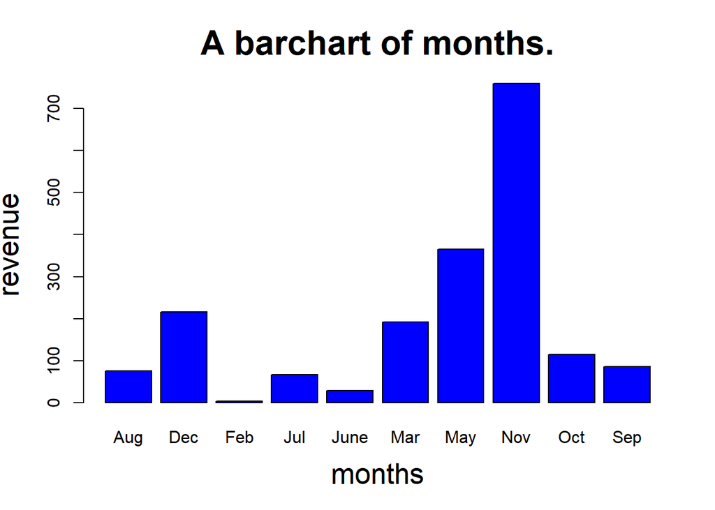

```r
#Bar chart to show frequency distribution of months
options(repr.plot.width = 10, repr.plot.height = 10)
barplot(c(month1.freq), main="A barchart of months.",
        xlab="months",
        ylab="revenue",
        cex.main=2, cex.lab=1.7,cex.sub=1.2,
        col=c("blue"))
```

```r
#comparison between operating systems and revenue brought in
#frequency table of Operating systems
os1.freq <- table(revenue$OperatingSystems)
sort(os1.freq, decreasing = TRUE)[1:5]
```

```
##
##    2    1    3    4    8
## 1155  379  268   85   17
```

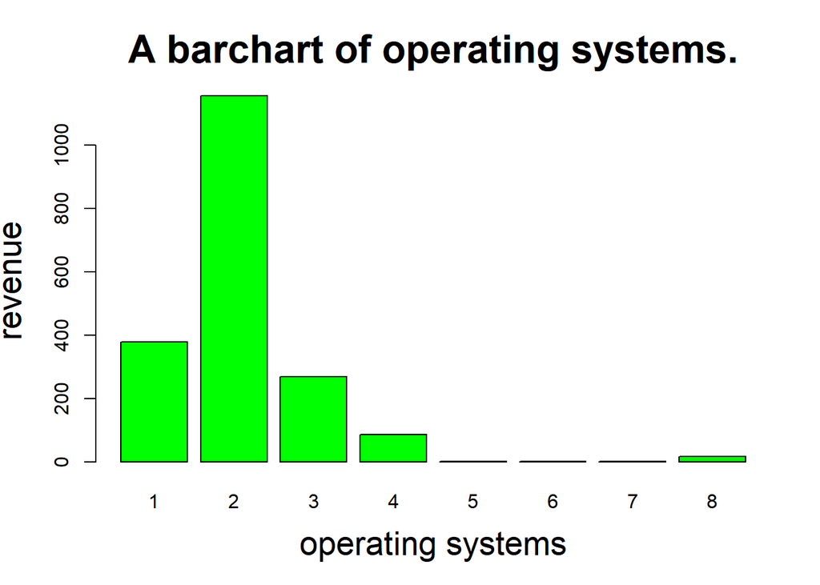

```r
#Bar chart to show frequency distribution of operating systems
options(repr.plot.width = 10, repr.plot.height = 10)
barplot(c(os1.freq), main="A barchart of operating systems.",
        xlab="operating systems",
        ylab="revenue",
        cex.main=2, cex.lab=1.7,cex.sub=1.2,
        col=c("green"))
```

```r
#comparison between browser and revenue brought in
#frequency table of browser
browser1.freq <- table(revenue$Browser)
sort(browser1.freq, decreasing = TRUE)[1:5]
```

```
##
##    2    1    4    5   10
## 1223  365  130   86   32
```

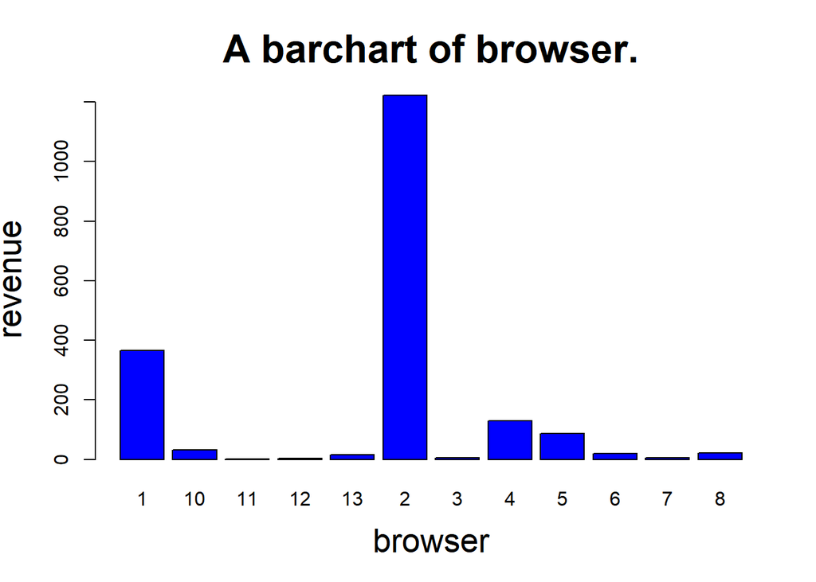

```r
#Bar chart to show frequency distribution of browsers
options(repr.plot.width = 10, repr.plot.height = 10)
barplot(c(browser1.freq), main="A barchart of browser.",
        xlab="browser",
        ylab="revenue",
        cex.main=2, cex.lab=1.7,cex.sub=1.2,
        col=c("blue"))
```

```r
#comparison between region and revenue brought in
#frequency table of region
region1.freq <- table(revenue$Region)
sort(region1.freq, decreasing = TRUE)[1:5]
```

```
##
##   1   3   2   4   7
## 771 349 188 175 119
```